# IdéesHal sous la loupe

S. Rey-Coyrehourcq, R. Krummeich

2024-03-20

# Exploiter l’API HAL avec les métadonnées adaptées

La librairie [`httr2`](https://httr2.r-lib.org/) permet de réaliser des requêtes API dans une syntaxe simple.

L’API HAL est décrite de manière sommaire et accessible par des supports de formation. On se limite ici à identifier les champs pertinents pour construire une table de données exploitables selon les usages habituels R. A cette fin, on mobilise aussi la librarie `arrow`, et celles plus classique`dplyr` etc.

## Nombre de notices HAL rattachées à l’UMR CNRS 6266 IDEES

### Identifier le périmètre du laboratoire

Une première étape est de trouver l’identifiant du laboratoire. Partant de la plateforme auréHAL,

https://aurehal.archives-ouvertes.fr/

il est possible d’effectuer des recherches. Par exemple, en sélectionnant les structures, on trouve la description actuelle du laboratoire et de ses tutelles.

https://aurehal.archives-ouvertes.fr/structure/read/id/97036

Le numéro de l’identifiant du laboratoire est : `97036`. Il s’agit de la première données HAL trouvée, correspondant au champ `structId_i`, défini comme *Structure: Internal structure identifier* au sein du schéma HAL, accessible en ligne :

https://api.archives-ouvertes.fr/docs/search/?schema=fields#fields

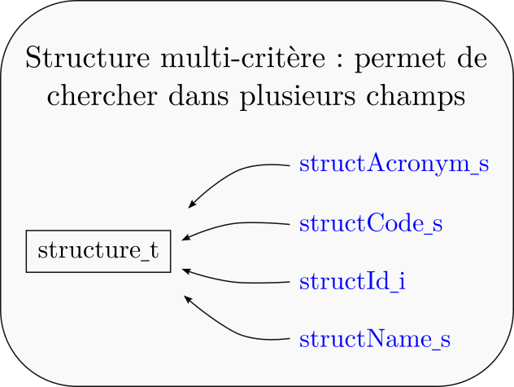

Le nombre de notices trouvées est de **2204** avec un rattachement au laboratoire d’identifiant HAL `97036`.

### Identifier les données HAL du laboratoire

Les données collectées par l’API HAL sont les suivantes :

|  | type de données |
| --- | --- |
| authIdHalFullName_fs | list |
| language_s | list |
| halId_s | list |
| docType_s | list |
| producedDateY_i | list |
| fileMain_s | list |
| doiId_s | list |

Les données collectées sont accessibles dans la table ci-dessous :

|  | authIdHalFullName_fs | language_s | halId_s | docType_s | producedDateY_i | fileMain_s | doiId_s |
| --- | --- | --- | --- | --- | --- | --- | --- |
| 1 | [['patrick-grave_FacetSep_Patrick Grave'], ['olivier-p-joly_FacetSep_Olivier Joly']] | [[['en']]] | ['hal-02125629'] | ['COMM'] | [2010] | [None] | [None] |
| 2 | [['_FacetSep_Jean-Claude Arnaud'], ['_FacetSep_Pierre Chapelet'], ['eric-leclerc_FacetSep_Eric Leclerc']] | [[['en']]] | ['hal-02403032'] | ['COUV'] | [2004] | [None] | [None] |
| 3 | [['patrick-grave_FacetSep_Patrick Grave'], ['olivier-p-joly_FacetSep_Olivier Joly']] | [[['fr']]] | ['hal-02123640'] | ['REPORT'] | [2010] | ['https://normandie-univ.hal.science/hal-02123640/document'] | [None] |
| 4 | [['olivier-p-joly_FacetSep_Olivier Joly'], ['patrick-grave_FacetSep_Patrick Grave']] | [[['fr']]] | ['hal-02122374'] | ['COMM'] | [2011] | [None] | [None] |
| 5 | [['patricia-sajous_FacetSep_Patricia Sajous'], ['_FacetSep_Valérie Bailly‐hascoët']] | [[['fr']]] | ['hal-01670588'] | ['ART'] | [2017] | ['https://hal.science/hal-01670588/document'] | ['10.4074/S0761898017002011'] |
| 6 | [[['_FacetSep_Claude Roccati']]] | [[['fr']]] | ['hal-01371879'] | ['COUV'] | [2015] | [None] | [None] |
| 7 | [[['_FacetSep_Claude Roccati']]] | [[['fr']]] | ['tel-01371669'] | ['THESE'] | [2014] | ['https://theses.hal.science/tel-01371669/document'] | [None] |
| 8 | [['galinon-melenec_FacetSep_Béatrice Galinon-Mélénec'], ['fabien-lienard_FacetSep_Fabien Liénard'], ['_FacetSep_Sami Zlitni']] | [[['fr']]] | ['hal-01317541'] | ['OUV'] | [2016] | [None] | [None] |
| 9 | [['philippe-vidal_FacetSep_Philippe Vidal'], ['alban-bourcier_FacetSep_Alban Bourcier'], ['loubet-lilian_FacetSep_Lilian Loubet']] | [[['fr']]] | ['hal-02507211'] | ['REPORT'] | [2013] | [None] | [None] |
| 10 | [['_FacetSep_Sami Zlitni'], ['fabien-lienard_FacetSep_Fabien Liénard'], ['galinon-melenec_FacetSep_Béatrice Galinon-Mélénec']] | [[['fr']]] | ['hal-02023538'] | ['COUV'] | [2015] | [None] | [None] |

[output cut: 2194 more lines]

#### Synthèse par type de document

Sur l’ensemble des données HAL attachées à l’UMR 6266 CNRS IDEES (toutes les années), la répartition des notices publiées par type de documents est la suivantes :

|  | Type.de.document | Nbre.Total | Nbre.d.idHal | Nbre.de.DOI.renseignés | Nbre.de.fichiers.attachés | Fr | En |
| --- | --- | --- | --- | --- | --- | --- | --- |
| 1 | ['COMM'] | 666 | 666 | 25 | 175 | 411 | 241 |
| 2 | ['ART'] | 659 | 659 | 367 | 273 | 400 | 247 |
| 3 | ['COUV'] | 382 | 382 | 62 | 97 | 278 | 98 |
| 4 | ['OUV'] | 126 | 126 | 13 | 15 | 101 | 24 |
| 5 | ['THESE'] | 86 | 86 | 0 | 85 | 84 | 2 |
| 6 | ['OTHER'] | 72 | 72 | 2 | 10 | 64 | 4 |
| 7 | ['REPORT'] | 59 | 59 | 0 | 35 | 43 | 16 |
| 8 | ['UNDEFINED'] | 35 | 35 | 1 | 28 | 14 | 21 |
| 9 | ['ISSUE'] | 27 | 27 | 7 | 2 | 22 | 4 |
| 10 | ['MAP'] | 26 | 26 | 0 | 26 | 0 | 0 |

[output cut: 10 more lines]

#### Synthèse par année

La répatition par année des notices publiées est reportée ci-dessous :

|  | Année | Nbre.Total | Nbre.d.IdHal | Nbre.de.DOI.renseignés | Nbre.ayant.un.fichier.attaché | Fr | En |
| --- | --- | --- | --- | --- | --- | --- | --- |
| 1 | 2024 | 23 | 23 | 8 | 10 | 10 | 13 |
| 2 | 2023 | 156 | 156 | 57 | 73 | 86 | 70 |
| 3 | 2022 | 121 | 121 | 41 | 41 | 79 | 40 |
| 4 | 2021 | 124 | 124 | 47 | 40 | 79 | 44 |
| 5 | 2020 | 92 | 92 | 34 | 44 | 67 | 22 |
| 6 | 2019 | 136 | 136 | 38 | 46 | 71 | 62 |
| 7 | 2018 | 118 | 118 | 25 | 41 | 78 | 38 |
| 8 | 2017 | 146 | 146 | 41 | 58 | 97 | 46 |
| 9 | 2016 | 167 | 167 | 32 | 73 | 104 | 37 |
| 10 | 2015 | 129 | 129 | 35 | 39 | 88 | 37 |

[output cut: 30 more lines]

## Créer un corpus textuel [WIP]

Il s’agit de définir un premier corpus textuel d’étude de champs thématiques émergents afin de permettre un dialogue entre les collègues des différents axes. Une première étape consiste à extraite les notices HAL disposant d’un document PDF attaché, c’est à dire une `uri` dans le champ `fileMain_s`.

### Résultats pour la période 2016-2020 (précédent quadriennal)

#### qualification du corpus : l’entrée PDF

Le corpus des notices HAL pour la catégorie “articles”, ayant un document attaché est résumé dans le tableau suivant :

| Année | Nbre total de notices HAL | Fr | En | Nbre de notices ayant un fichier attaché | Nbre articles PDF | Nbre articles PDF FR | Nbre articles PDF EN |
| --- | --- | --- | --- | --- | --- | --- | --- |
| 2016 | 167 | 104 | 37 | 73 | 18 | 12 | 6 |
| 2017 | 146 | 97 | 46 | 58 | 22 | 13 | 9 |
| 2018 | 118 | 78 | 38 | 41 | 7 | 4 | 3 |
| 2019 | 136 | 71 | 62 | 46 | 19 | 3 | 16 |
| 2020 | 92 | 67 | 22 | 44 | 18 | 11 | 7 |

Il y a 84 documents dans la catégorie “article” dans ce corpus, dont :

- 43 en français,
- et 41 en anglais,

soit environ 32% des identifiants HAL pour la période ayant un document attaché à la notice,

- 16% en français,
- et 15% en anglais,

et environ 12% de l’ensemble des notices HAL sur la période,

- 6% en français,
- et 6% en anglais,

#### qualification du corpus : les auteurs et autrices

|  | Var1 | Freq |
| --- | --- | --- |
| 1 | Abrantes | 2 |
| 2 | Achouri | 1 |
| 3 | Adam | 2 |
| 4 | Adjizian-Gérard | 1 |
| 5 | Álvarez-Lao | 1 |
| 6 | Álvarez-Vena | 1 |
| 7 | Audibert | 1 |
| 8 | Audra | 1 |
| 9 | Bailly‐hascoët | 1 |
| 10 | Ballesteros | 3 |

[output cut: 189 more lines]

### Résultats pour la période 2021-2024 (quadriennal actuel)

#### qualification du corpus : l’entrée PDF

Le corpus des notices HAL pour la catégorie “articles”, ayant un document attaché est résumé dans le tableau suivant :

| Année | Nbre total de notices HAL | Fr | En | Nbre de notices ayant un fichier attaché | Nbre articles PDF | Nbre articles PDF FR | Nbre articles PDF EN |
| --- | --- | --- | --- | --- | --- | --- | --- |
| 2021 | 124 | 79 | 44 | 40 | 20 | 12 | 8 |
| 2022 | 121 | 79 | 40 | 41 | 19 | 6 | 13 |
| 2023 | 156 | 86 | 70 | 73 | 26 | 9 | 17 |
| 2024 | 23 | 10 | 13 | 10 | 3 | 0 | 3 |

Il y a 68 documents dans la catégorie “article” dans ce corpus, dont :

- 27 en français,
- et 41 en anglais,

soit environ 41% des identifiants HAL pour la période ayant un document attaché à la notice,

- 16% en français,
- et 25% en anglais,

#### qualification du corpus : les auteurs et autrices

|  | Var1 | Freq |
| --- | --- | --- |
| 1 |  | 2 |
| 2 | Abcha | 1 |
| 3 | Abd El Sater | 1 |
| 4 | Ahmed-Delacroix | 1 |
| 5 | Aïta Cissé | 1 |
| 6 | Alemparte | 1 |
| 7 | Alexandre | 1 |
| 8 | Amat | 1 |
| 9 | Antoine | 1 |
| 10 | Antonio López-Sáez | 1 |

[output cut: 294 more lines]